# Working with Oceanographic Data: FRRf Data

```r
library(TheSource)
```

Once we have TheSource loaded, then we can load one or more FRRf datafiles with the *load.frrf()* function. By default, the function will load all files within the target directory (and will throw an error if there are other files in that directory!), but to ensure proper functioning it is a good idea to explicitly state the file names you want, e.g.:

```r
frrf = load.frrf(input.dir = '../../../CCE/CCEP1706/Data/FRRF/', file.names = frrf.files)
```

```r
names(frrf)[1:10]
```

[output not shown]

This dual syntax is useful since there are times when we will want to manually select (or be able to read at least) which dataset we are referencing, but also times when we want to loop over all available datasets (e.g. when fitting curves to specific data).

Each FRRf dataset is itself a list object with 8 fields (4 of which are LED light modes). The structure of a dataset may look intimidating at first, but it is simply a reflection of the raw FRRf data itself and simple to navigate once familiar with it.

```r
str(frrf[[1]], max.level = 2)
```

[output not shown]

[output cut: 58 more lines]

[output not shown]

Let’s plot an example and do a curve fit:

```r
plot(frrf[[1]]$A$E, frrf[[1]]$A$JVPII, pch = 16, xlab = 'Light Intensity', ylab = 'JVPII')
```

[output not shown]

To fit a curve we need to define an objective function and a functional form. We will use a Platt et al fit, which comes pre-loaded in *TheSource*, so all we need to do is make a cost function so the grid search algorithm can find us a “best fit”.

```r
ssr = function(alpha, beta, Ps, E, JVPII) {
  predicted = model.Platt1980(alpha = alpha, beta = beta, Ps = Ps, E = E)
  cost = sum((predicted - JVPII)^2)

  cost
}
```

With this function, we provide a value for *alpha*, *beta*, *Ps*, and a set of light intensities and JVPII and it returns the sum of squared residuals *or cost*.

```r
fit = parameter.search(n = 5, cost = ssr, bounds = data.frame(min = c(0, 0, 1), max = c(1, 0.01, 10)), splits = 20, E = frrf[[1]]$A$E, JVPII = frrf[[1]]$A$JVPII, verbose = F)
```

Let’s see how our fit did:

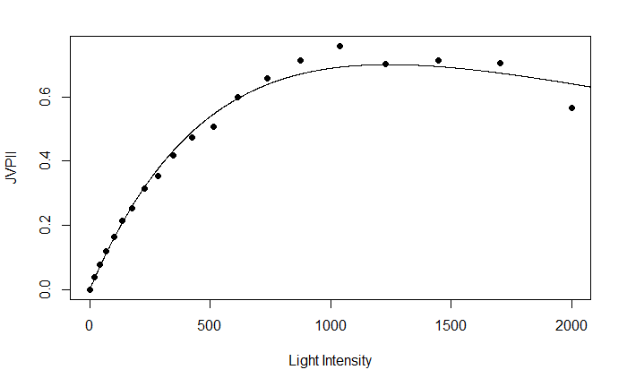

```r
plot(frrf[[1]]$A$E, frrf[[1]]$A$JVPII, pch = 16, xlab = 'Light Intensity', ylab = 'JVPII')

## Add the fit
E = c(1:3e3)
jvpii = model.Platt1980(alpha = fit$min$alpha, beta = fit$min$beta, Ps = fit$min$Ps, E = E)
lines(E, jvpii)
```

This fit did pretty well, but note that as always a multidimensional optimization procedure is generally unstable and may vary significantly based on initial conditions!

For example, the same routine but with a “poor” choice in beta values (set the max too high):

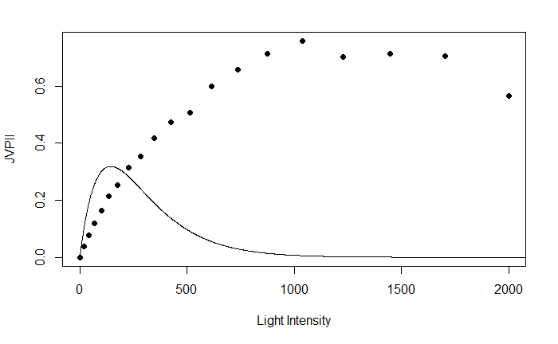

```r
bad.fit = parameter.search(n = 5, cost = ssr, bounds = data.frame(min = c(0, 0, 1), max = c(1, 1, 10)), splits = 20, E = frrf[[1]]$A$E, JVPII = frrf[[1]]$A$JVPII, verbose = F)

plot(frrf[[1]]$A$E, frrf[[1]]$A$JVPII, pch = 16, xlab = 'Light Intensity', ylab = 'JVPII')

## Add the fit
E = c(1:3e3)
jvpii = model.Platt1980(alpha = bad.fit$min$alpha, beta = bad.fit$min$beta, Ps = bad.fit$min$Ps, E = E)
lines(E, jvpii)
```